```python
from IPython.display import HTML

HTML('''<script>
code_show=true;
function code_toggle() {
 if (code_show){
 $('div.input').hide();
 } else {
 $('div.input').show();
 }
 code_show = !code_show
}
$( document ).ready(code_toggle);
</script>
<form action="javascript:code_toggle()"><input type="submit" value="Click here to toggle on/off the raw code."></form>''')
```

# $Project: Investigate\, a\, Dataset$

### *Introduction*

*For this project, I have chosen to work with the Titanic dataset. Over the course of this project, I will be attempting to understand the Titanic dataset, ask questions regarding it, clean it and visualize it as I go along. This is just a humble attempt to investigate this dataset. Suggestions to improve the overall analysis and quality of the submission will be very much appreciated.*

*I will be using standard data analysis and visualization libraries like pandas, Numpy, matplotlib, seaborn and more, to examine and communicate my findings about the data along the way.*

### *Background: RMS Titanic*

*Titanic was the largest ship afloat at the time of her sailing. On April 10, 1912, she made her maiden voyage. Five days later, on April 15, 1912, she sank after colliding with an iceberg, killing 1502 out of 2224 passengers and crew on board. These figures translate to a 32% survival rate.*

*One of the biggest reason the shipwreck caused such huge loss of life, was the shortage of lifeboats for the passengers and crew. Those who were lucky enough to survive were largely either women or children maybe because of "women and children first" policy, or they might have belonged to the upper-class.*

*I am going to be analyizing The Titanic dataset that contains demographics and passenger information from about 40% (891 of the 2224) passengers and crew on board the Titanic.*

### *Import Libraries*

*Loading data analysis and visualization libararies I am going to be working with on this project.*

```python
# Importing data analysis and visualization libraries
import pandas as pd
import numpy as np
from numpy import random
import matplotlib.pyplot as plt
from pylab import *
import seaborn as sns
sns.set_style('whitegrid')
%matplotlib inline
```

### *Load Data*

*Pandas library is probably the most efficient library to import and manage datasets. Here, I am going to be using it to read the dataset into neat and crisp Pandas DataFrames.*

```python
# load dataset
titanic_dataset = pd.read_csv("train.csv")
```

*Before previewing the DataFrame, I'd like to take a peek at the basic structure of the dataset to see,*

- *number of rows and columns*
- *names of the available variables*

```python
# Basic index and column structure
print(titanic_dataset.shape)
print("The dataset contains 891 rows and 12 columns")
```

```
(891, 12)
The dataset contains 891 rows and 12 columns
```

```python
# Check names of variables
print(list(titanic_dataset))
# print(titanic_dataframe.columns.values)
```

```
['PassengerId', 'Survived', 'Pclass', 'Name', 'Sex', 'Age', 'SibSp', 'Parch', 'Ticket', 'Fare', 'Cabin', 'Embarked']
```

*These variables were already described on this [Kaggle](https://www.kaggle.com/c/titanic/data) page from where the dataset was downloaded. Nevertheless, I am defining them again just to keep every thing well documented in this notebook.*

```python
# creating an explainer dataframe that defines the variables available in the dataset.
definitions = pd.DataFrame({"Variable":["Survived", "pClass","Sex","Age","Sibsp", "Parch", "Ticket", "Fare", "Cabin", "Embarked"],
                         "Definition":["Survived (0 = No, 1 = Yes)", "Ticket class (1 = 1st, 2 = 2nd, 3 = 3rd)", "Gender", "Age in years", "# of siblings / spouses aboard the Titanic",
                                      "# of parents / children aboard the Titanic", "Ticket number", "Passenger fare", "Cabin number",
                                      "Port of Embarkation (C = Cherbourg, Q = Queenstown, S = Southampton)"]})
# change order of the dataframe columns
ordered_df = definitions[["Variable", "Definition"]]
ordered_df
```

|  | Variable | Definition |
| --- | --- | --- |
| 0 | Survived | Survived (0 = No, 1 = Yes) |
| 1 | pClass | Ticket class (1 = 1st, 2 = 2nd, 3 = 3rd) |
| 2 | Sex | Gender |
| 3 | Age | Age in years |
| 4 | Sibsp | # of siblings / spouses aboard the Titanic |
| 5 | Parch | # of parents / children aboard the Titanic |
| 6 | Ticket | Ticket number |
| 7 | Fare | Passenger fare |
| 8 | Cabin | Cabin number |
| 9 | Embarked | Port of Embarkation (C = Cherbourg, Q = Queens... |

*Next step is to preivew the data. This is how the first and last 3 entires look,*

```python
# preview the first 3 rows
titanic_dataset.head(3)
```

|  | PassengerId | Survived | Pclass | Name | Sex | Age | SibSp | Parch | Ticket | Fare | Cabin | Embarked |
| --- | --- | --- | --- | --- | --- | --- | --- | --- | --- | --- | --- | --- |
| 0 | 1 | 0 | 3 | Braund, Mr. Owen Harris | male | 22.0 | 1 | 0 | A/5 21171 | 7.2500 | NaN | S |
| 1 | 2 | 1 | 1 | Cumings, Mrs. John Bradley (Florence Briggs Th... | female | 38.0 | 1 | 0 | PC 17599 | 71.2833 | C85 | C |
| 2 | 3 | 1 | 3 | Heikkinen, Miss. Laina | female | 26.0 | 0 | 0 | STON/O2. 3101282 | 7.9250 | NaN | S |

```python
# preview the last 3 rows
titanic_dataset.tail(3)
```

|  | PassengerId | Survived | Pclass | Name | Sex | Age | SibSp | Parch | Ticket | Fare | Cabin | Embarked |
| --- | --- | --- | --- | --- | --- | --- | --- | --- | --- | --- | --- | --- |
| 888 | 889 | 0 | 3 | Johnston, Miss. Catherine Helen "Carrie" | female | NaN | 1 | 2 | W./C. 6607 | 23.45 | NaN | S |
| 889 | 890 | 1 | 1 | Behr, Mr. Karl Howell | male | 26.0 | 0 | 0 | 111369 | 30.00 | C148 | C |
| 890 | 891 | 0 | 3 | Dooley, Mr. Patrick | male | 32.0 | 0 | 0 | 370376 | 7.75 | NaN | Q |

*I thought it'll be good practice to keep a record of catagorical and quantitave variables.*

*Categorical variables:*  
*Categorical variables consist of nominal, ordinal, ratio, or interval based values. In this dataset Survived, Sex, and Embarked are catagorical variables while Pclass is ordinal.*

*Quantitave variables:*  
*Quantitave variables consist of discrete, continuous, or timeseries based values. In this dataset, Age and Fare are continuous variables while SibSp and Parch are discrete.*

*I also wanted to know what kind of data types the dataset contains. This info could be useful incase I needed to convert any of them in the future.*

```python
# dataset at a glance.
titanic_dataset.info()
# an overview of the dataset showing column names and number of rows
# in each column. Also shows missing values in the dataset and data types.
```

```
<class 'pandas.core.frame.DataFrame'>
RangeIndex: 891 entries, 0 to 890
Data columns (total 12 columns):
PassengerId    891 non-null int64
Survived       891 non-null int64
Pclass         891 non-null int64
Name           891 non-null object
Sex            891 non-null object
Age            714 non-null float64
SibSp          891 non-null int64
Parch          891 non-null int64
Ticket         891 non-null object
Fare           891 non-null float64
Cabin          204 non-null object
Embarked       889 non-null object
dtypes: float64(2), int64(5), object(5)
memory usage: 83.6+ KB
```

*The dataset contains 5 integer variables, 2 floats and 5 strings (labeled as object). The information also revealed that variables Age, Cabin and Embarked had missing values.*

```python
# checking how many values are missing.
titanic_dataset.isnull().sum()
```

```
PassengerId      0
Survived         0
Pclass           0
Name             0
Sex              0
Age            177
SibSp            0
Parch            0
Ticket           0
Fare             0
Cabin          687
Embarked         2
dtype: int64
```

*Variable Age has about 20% missing values (177/891)*  
*Variable Cabin has about 77.0% missing values (687/891)*  
*Variable Embarked has about 0.22% missing values (2/891)*

*I'll deal with missing values in a later section of the notebook. For the time being, I'll generate some quick descriptive statistics from the available data and take this investigation forward.*

```python
# summary of central tendency, dispersion and shape of the dataset’s distribution,
# excluding NaN values.
titanic_dataset.describe().drop("PassengerId", axis=1)
```

|  | Survived | Pclass | Age | SibSp | Parch | Fare |
| --- | --- | --- | --- | --- | --- | --- |
| count | 891.000000 | 891.000000 | 714.000000 | 891.000000 | 891.000000 | 891.000000 |
| mean | 0.383838 | 2.308642 | 29.699118 | 0.523008 | 0.381594 | 32.204208 |
| std | 0.486592 | 0.836071 | 14.526497 | 1.102743 | 0.806057 | 49.693429 |
| min | 0.000000 | 1.000000 | 0.420000 | 0.000000 | 0.000000 | 0.000000 |
| 25% | 0.000000 | 2.000000 | 20.125000 | 0.000000 | 0.000000 | 7.910400 |
| 50% | 0.000000 | 3.000000 | 28.000000 | 0.000000 | 0.000000 | 14.454200 |
| 75% | 1.000000 | 3.000000 | 38.000000 | 1.000000 | 0.000000 | 31.000000 |
| max | 1.000000 | 3.000000 | 80.000000 | 8.000000 | 6.000000 | 512.329200 |

*PassengerId is basically just another index to keep a count of passengers on board. It has no use in the statistical summary so I dropped it from the description table. The rest of the table quite conviniently displays the statistics for the required variables.* *The statistics for the Age variable will change once I impute those missing values.*

### *Correlation Matrix*

*This is a good time to plot a correlation matrix to see how each numerical variable is correlated with other numerical variable. I excluded PassengerID because it is just an index, as I mentioned before. In the plot, stronger positive correlations are expressed in darker blue, while stronger negative correlations are expressed in darker red. The closer to white a colour gets the weaker the correlation becomes.*

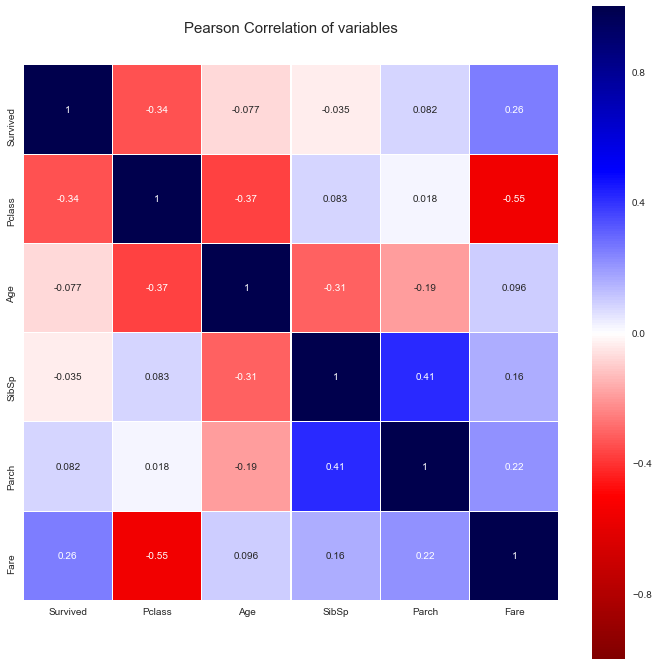

```python
# plotting a correlation matrix
colormap = plt.cm.seismic_r
plt.figure(figsize=(12,12))
plt.title("Pearson Correlation of variables", y=1.05, size=15)
sns.heatmap(titanic_dataset.drop("PassengerId", axis=1).corr(),linewidths=0.1,vmax=1.0, square=True, cmap=colormap, linecolor='white', annot=True)
```

```python
# checking correlation of variables with Survived
titanic_dataset.corr()["Survived"].drop("PassengerId", axis=0)
```

```
Survived    1.000000
Pclass     -0.338481
Age        -0.077221
SibSp      -0.035322
Parch       0.081629
Fare        0.257307
Name: Survived, dtype: float64
```

*What I am most interested in seeing through this matrix, is a correlation between Survived and other variables. So far, only Fare and Pclass seem to have a decent correlation with Survived in comparison to other numerical variable in the matrix.*

*Now that a bit of foundation has been laid, I can start digging for the answer to the big question:*  
**What factors made it more likely for a person to survive on the Titanic?**  
In order to find any kind of satisfactory answer, I will break the analysis down in smaller chunks to be able be to explore the dataset from many different aspects.

### Sex

*Despite the correlation matrix showing relationship between Survived, Pclass and Fare, I chose to start the investigation with gender. There is no particular reason for this, except that I wanted to start with something as basic as sex.*

*In this section I will compare survivors and non-survivors by gender. This will allow me to investigate the dataset by asking questions like:*  
**• How many passengers on board were females and how many were males?**  
**• What was the proportion of female survivors compared to male survivors?**

*Futhermore, I will extract the titles from the Name column, engineer a new column called Title and add those extracted titles to this new column. This will help me to investigate:*  
**• How many Mrs, Mr, Miss, Master and other titles were in the sample?**  
**• How many survivied?**

```python
# check number of females in the total sample.
female_count = titanic_dataset[titanic_dataset["Sex"]=="female"]["Sex"].count()
print("Total number female passengers {}".format(female_count))
```

```
Total number female passengers 314
```

```python
# check number of males in the total sample.
male_count = titanic_dataset[titanic_dataset["Sex"]=="male"]["Sex"].count()
print("Total number male passengers {}".format(male_count))
```

```
Total number male passengers 577
```

```python
# check numbers for survivors and non-survivors
survivors = titanic_dataset[titanic_dataset['Survived']==1]
no_survivors = titanic_dataset[titanic_dataset['Survived']==0]
survivor_percentage = round((survivors["Survived"].count()/len(titanic_dataset))*100, 2)
non_survivor_percentage = round((no_survivors["Survived"].count()/len(titanic_dataset))*100, 2)
print("Passengers Survived: {}%, Passengers Deceased: {}%, Total Passengers: {}".format(survivor_percentage, non_survivor_percentage, len(titanic_dataset)))
```

```
Passengers Survived: 38.38%, Passengers Deceased: 61.62%, Total Passengers: 891
```

```python
# check gender wise survivors
survival_by_gender = titanic_dataset.groupby("Sex")["Survived"].sum() # sum of all who survived in dataframe grouped by sex
female_survivors = survival_by_gender.loc["female"]
print("Number of female suvivors {}".format(female_survivors))
male_survivors = survival_by_gender.loc["male"]
print("Number of male survivors {}".format(male_survivors))
```

```
Number of female suvivors 233
Number of male survivors 109
```

```python
# extracting titles
for titles in titanic_dataset:
    titanic_dataset["Title"] = titanic_dataset.Name.str.extract(' ([A-Za-z]+)\.')
```

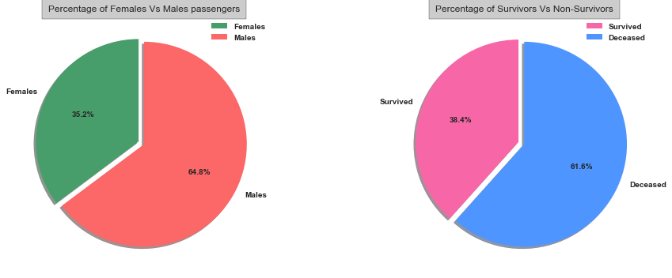

```python
# plotting pie charts
# set typeface, weight, typesize for labels and legends
font = {'family' : 'arial',
        'weight' : 'bold',
        'size'   : 10}

matplotlib.rc('font', **font)

# Make square figures and axes
fig = plt.figure(figsize=(15,5))
the_grid = GridSpec(1, 2)

# plot number of female vs number of male passengers
plt.subplot(the_grid[0, 0], aspect=1)
plt.pie([female_count, male_count], explode=[0.06, 0], labels=["Females", "Males"], colors=["#489e6a","#fc6767"],
        autopct='%1.1f%%', shadow=True, startangle=90)
title('Percentage of Females Vs Males passengers', bbox={'facecolor':'0.8', 'pad':8})
plt.legend(loc="upper right")

# plot female vs male survivors
plt.subplot(the_grid[0, 1], aspect=1)
plt.pie([survivor_percentage, non_survivor_percentage],
        explode=[0.06, 0], labels=["Survived", "Deceased"],colors=["#f767a8","#4f95ff"], autopct='%1.1f%%', shadow=True
        ,startangle=90)
title('Percentage of Survivors Vs Non-Survivors', bbox={'facecolor':'0.8', 'pad':8})
plt.legend(loc="upper right")

plt.tight_layout()
```

```
      Sex  Survived
0  female  0.742038
1    male  0.188908
```

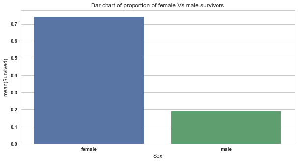

```python
# plotting average survival rate of females vs males
data = titanic_dataset[["Survived", "Sex"]].groupby(["Sex"], as_index=False).mean()
plt.subplots(1, figsize=(10,5))
sns.barplot(x="Sex", y="Survived", data=data)
plt.title("Bar chart of proportion of female Vs male survivors")
print(data)
```

```python
# checking number of passengers per title
print(titanic_dataset["Title"].value_counts())
```

```
Mr          517
Miss        182
Mrs         125
Master       40
Dr            7
Rev           6
Mlle          2
Col           2
Major         2
Jonkheer      1
Don           1
Capt          1
Sir           1
Lady          1
Ms            1
Countess      1
Mme           1
Name: Title, dtype: int64
```

```
            0    1         2    3         4         5     6      7       8   \
Title     Capt  Col  Countess  Don        Dr  Jonkheer  Lady  Major  Master
Survived     0  0.5         1    0  0.428571         0     1    0.5   0.575

                9     10   11        12     13  14   15   16
Title         Miss  Mlle  Mme        Mr    Mrs  Ms  Rev  Sir
Survived  0.697802     1    1  0.156673  0.792   1    0    1
```

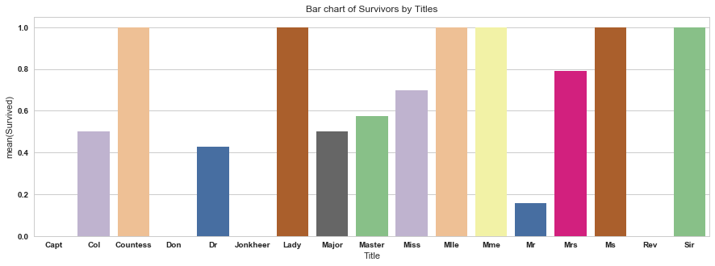

```python
# plotting average survival rate of passengers by title
plt.subplots(1, figsize=(15,5))
titles_surv = titanic_dataset[["Title", "Survived"]].groupby(["Title"], as_index=False).mean()
sns.barplot(x="Title", y="Survived",data=titles_surv, palette="Accent")
plt.title("Bar chart of Survivors by Titles")
print(titles_surv.transpose())
```

*In summary, out of the 891 passengers on board, 35% (314) were females and 65% (577) were males. There is a clear indication that females had a far better survival rate than males. About 74%, 233 out of 314 females survived, while only about 19%, 109 out of 577 males could survive.*

*Passengers with titles including Miss, Master, and Mrs further suggest, that females and children had better chances of survival than older males. Hopefully, a comparison by age will further shed some light on this assumption.*

*As I mentioned, the proportion of females survivors compared to males survivors was far greater. One reason for this difference could have been the "women and children first" policy that might have allowed more women to be saved.*  
*To test whether this difference had any statistical significance I'll conduct a one tailed z test, at an alpha level of 0.01. M will be proportion of male survivals, F will be proportion of female survivals.*

*Null hypothesis for this test is: proportion of female to male survivors is equal.* $$H_o: F_{proportion} = M_{proportion}$$

*Alternate hypothesis for this test is: proportion of female survivors is greater than male survivors.* $$H_a: F_{proportion} > M_{proportion}$$

```python
# importing math library
import math
# setting up sample size and means
f_sample = 314
F_proportion = round(0.7420382165605095, 4)

m_sample = 577
M_proportion = round(0.18890814558058924, 4)

# calculating pooled variance
pooled_variance = (F_proportion * f_sample + M_proportion * m_sample) / (f_sample + m_sample)

# calculating standard error
std_err = math.sqrt(pooled_variance * (1 - pooled_variance) * ((1/f_sample) + 1/m_sample))

# calculating Z score
z_score = round((F_proportion - M_proportion)/std_err, 2)
print("Z score for the test is:",z_score)
```

```
Z score for the test is: 16.22
```

*Since 16.22 > 2.33, I reject the null that proportions are equal. There is indeed, statistical evidence that if a passenger were to be a female, her chances of survival were greater.*

### *Age*

*In this section I will compare survivors and non-survivors by Age. I will be investigating the dataset by asking questions like:*  
**• How old were Survivors compared to Non-Survivors?**  
**• How old were females survivors compared to males survivors?**  
**• Did age effect chances of survival?**  
*which could lead to some interesting connections between Age, Sex and Survival.*

*To begin this analysis, I will first impute those missing values. My strategy is to replace null values by the median age of the samples.*

### *Dealing with missing age data*

```python
# importing sklearn to deal with missing values
from sklearn.preprocessing import Imputer
# setting up imputation for missing values
imputer = Imputer(missing_values="NaN", strategy="median", axis=0)
# slicing the Age column from the dataframe
missing_age = titanic_dataset.iloc[:, 5:6]
# fitting the imputer on missing values
imputer = imputer.fit(missing_age)
# imputing all missing values
titanic_dataset["Age"] = imputer.transform(missing_age)
# converting Age to from float to int
titanic_dataset['Age'] = titanic_dataset['Age'].astype(int)
#print("Number of missing values in the Age column:",titanic_dataset["Age"].isnull().sum())
```

*Now that missing values have been substituted, I'll proceed forward with the investigation.*

```python
# checking age statistics for the entire sample
titanic_dataset["Age"].describe()
# slight alteration in values from before
```

```
count    891.000000
mean      29.345679
std       13.028212
min        0.000000
25%       22.000000
50%       28.000000
75%       35.000000
max       80.000000
Name: Age, dtype: float64
```

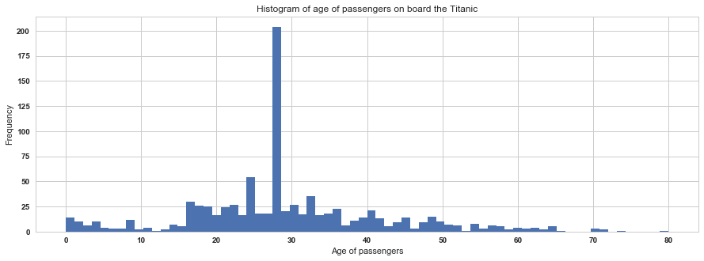

```python
# Plotting a histogram to see the distribution of age of all passengers on board.
plt.subplots(1, figsize=(15,5))
plt.hist(titanic_dataset["Age"],bins=70)
plt.xlabel("Age of passengers")
plt.ylabel("Frequency")
plt.title("Histogram of age of passengers on board the Titanic")
```

*The histogram shows the distrubtion of age of all samples. That big spike around the 28-29 age mark is probably because of the adjusted age values. Rest of the values look evenly distributed with most values being almost between 18 - 35 mark.*

```python
# grouping survived and age by survived
titanic_dataset[["Survived", "Age"]].groupby("Survived").describe().transpose()
```

| Survived | 0 count | 0 mean | 0 std | 0 min | 0 25% | 0 50% | 0 75% | 0 max | 1 count | 1 mean | 1 std | 1 min | 1 25% | 1 50% | 1 75% | 1 max |
| --- | --- | --- | --- | --- | --- | --- | --- | --- | --- | --- | --- | --- | --- | --- | --- | --- |
| Age | 549.0 | 30.01275 | 12.493568 | 1.0 | 23.0 | 28.0 | 35.0 | 74.0 | 342.0 | 28.274854 | 13.7947 | 0.0 | 21.0 | 28.0 | 35.0 | 80.0 |

*These statistics indicate that survivors were, on an average, couple of years younger than non survivor. The average age of a survivor was about 28 years, while the average age of a non-survivor was about 30 years. The median age was 28 years in both the cases. A side by side comparison of histograms of age of survivors vs non-survivors, shows this better.*

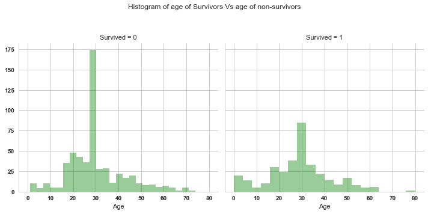

```python
# plotting histograms
g = sns.FacetGrid(titanic_dataset, col='Survived',size=5, aspect=1)
g.map(sns.distplot, "Age", hist=True, kde=False, color="green")
plt.subplots_adjust(top=0.8)
g.fig.suptitle('Histogram of age of Survivors Vs age of non-survivors')
```

```python
# grouping age, survived and sex by survived
titanic_dataset[["Survived", "Age", "Sex"]].groupby("Sex").describe().drop("Survived", axis=1).transpose()
```

| Sex | female count | female mean | female std | female min | female 25% | female 50% | female 75% | female max | male count | male mean | male std | male min | male 25% | male 50% | male 75% | male max |
| --- | --- | --- | --- | --- | --- | --- | --- | --- | --- | --- | --- | --- | --- | --- | --- | --- |
| Age | 314.0 | 27.920382 | 12.871323 | 0.0 | 21.0 | 28.0 | 35.0 | 63.0 | 577.0 | 30.121317 | 13.058596 | 0.0 | 23.0 | 28.0 | 35.0 | 80.0 |

*Histograms below give a good indication of distribution of age by sex for survivors and non-survivors.*